# Geneweaver

This notebook implement the download the geneset for functional enrichment analysis

GeneWeaver is a web-based platform designed to integrate and analyze diverse types of functional genomics data, especially related to genes and their roles in biological processes. It allows researchers to collect, organize, and perform analyses on genetic data from different sources, facilitating the discovery of relationships between genes and various phenotypes (traits or diseases).

### 1. Searching for a Phenotype

You can search for any phenotype of interest, such as binge drinking, using the search functionality on the platform. After entering your desired phenotype, a list of associated gene sets will appear. Carefully review these gene sets and select the one(s) that are most relevant to your research. Once you've selected the gene sets, click on the ‘Add Selected to Project’ button to proceed. This step allows you to build a project around the selected gene sets for further analysis.

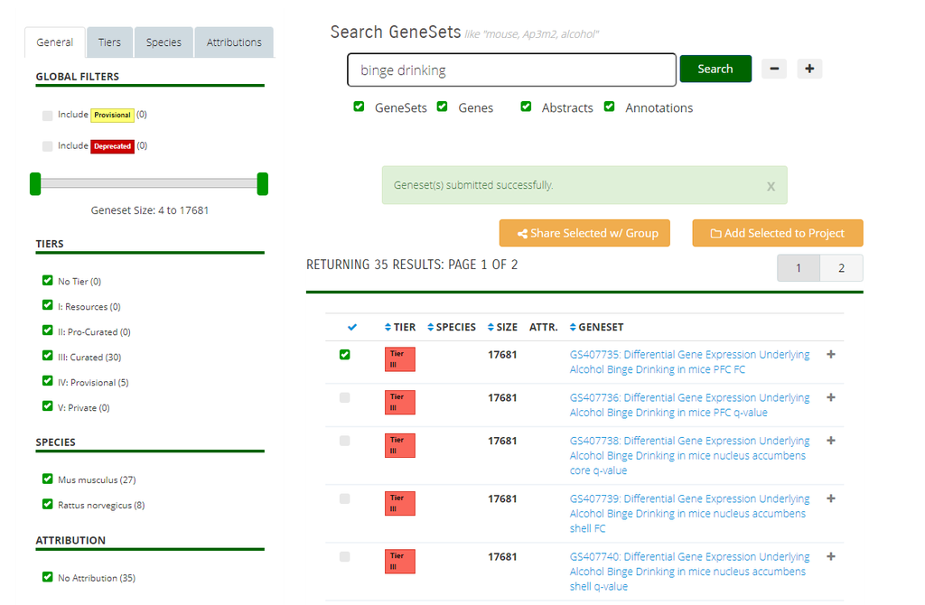

```r
IRdisplay::display_png(file = "search.png")
```

### 2. Creating or Adding to a Project

After clicking the ‘Add Selected to Project’ button, you'll be presented with an option to either create a new project or add the gene sets to an existing project. If you're working on a new analysis, create a new project by providing a name and description. If the gene sets relate to an ongoing analysis, choose the existing project from the list. Once your selection is made or the project is created, click the Submit button to finalize your action.

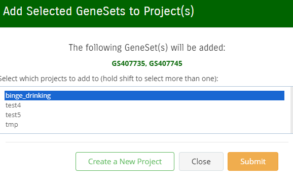

```r
IRdisplay::display_png(file = "add_project.png")
```

### 3. Analyzing Gene Sets in a Project

To analyze the gene sets you’ve added to your project, navigate to the ‘Analyze Gene Sets and Projects’ section. Here, you can select the name of your project from the dropdown menu. Once the project is selected, you'll see an analysis tool menu. Under the Boolean Algebra category, select either Union (to combine gene sets) or Intersection (to identify genes common between sets). After selecting your desired operation, click the Analyze button to proceed with the gene set comparison.

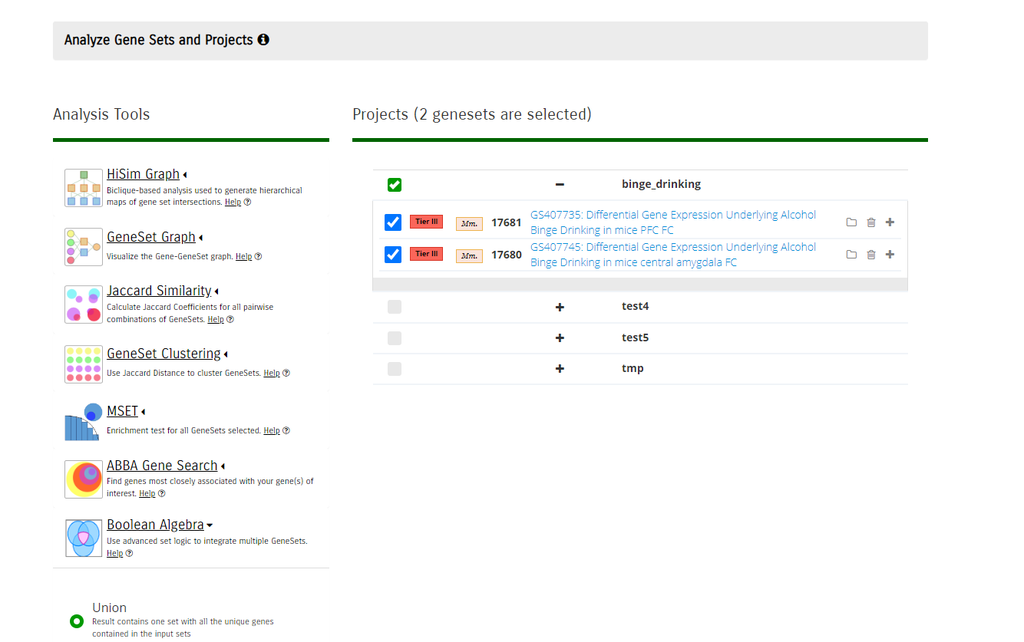

```r
IRdisplay::display_png(file = "boolean_algebra.png")
```

### 4. Viewing the Interaction of Gene Sets

After running the Boolean Algebra analysis, you will be able to view the interaction between the selected gene sets. This visualization shows how genes from different sets overlap or interact. Once you are satisfied with the analysis, you can create a new gene set based on the results by clicking the ‘Create New Geneset From Results’ button. This new gene set can be further explored, analyzed, or saved for future use

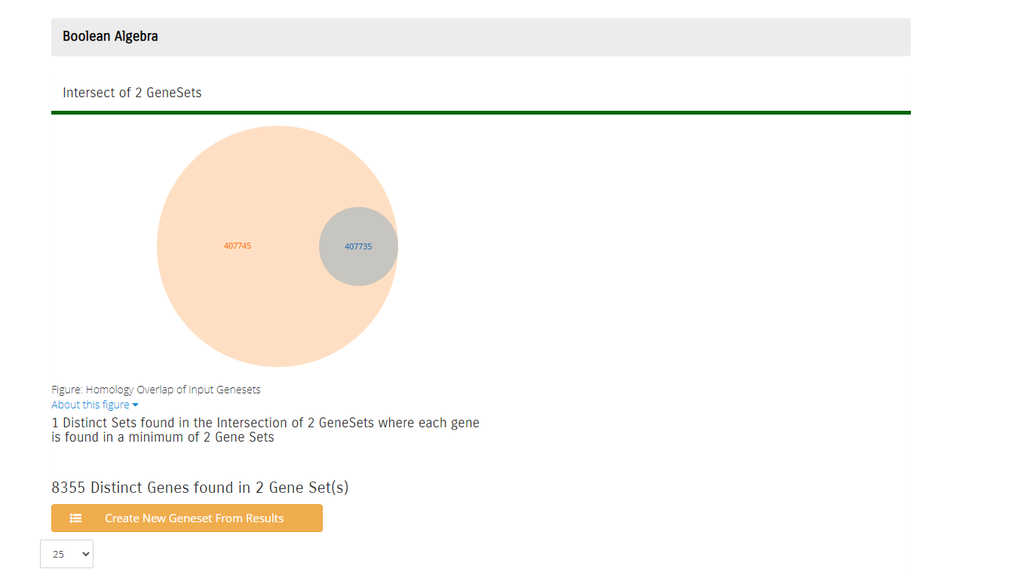

```r
IRdisplay::display_png(file = "union_gene.png")
```

### 5. Matching the Reference Panel

Before finalizing your new gene set, ensure that the reference panel you select matches the species or genome build of the gene set you're working with. For example, if your gene set is based on the human genome, make sure the reference panel is also human-based. If you select a mismatched reference panel, the system won’t be able to map gene names correctly, and they won’t appear in the output. Always verify that the reference panel aligns with your gene set’s source data.

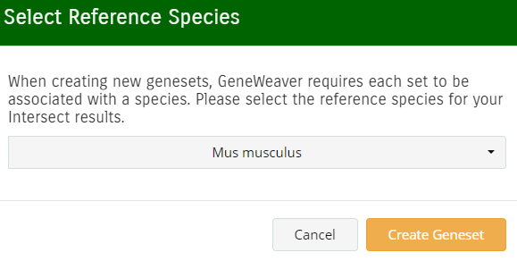

```r
IRdisplay::display_png(file = "ref_gene.png")
```

### 6. Providing Gene Set Information

When creating a new gene set from your analysis, it's important to provide detailed information about the gene set. This may include its source, the method of selection, any associated phenotypes, and any additional metadata that will help describe the gene set. This information ensures that your gene set is well-documented and can be easily interpreted by other researchers or collaborators.

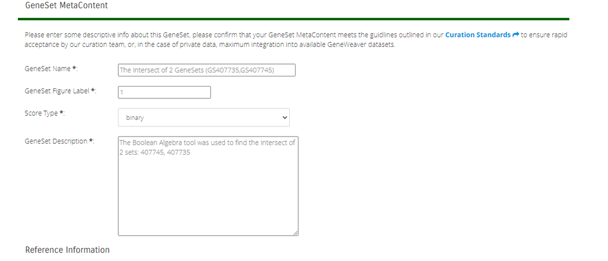

```r
IRdisplay::display_png(file = "geneset_ref.png")
```